# Improvements Needed

One approach would be to use the cuttrend parameter (available both in Nordpred and multiAPCMC). What does that look like?

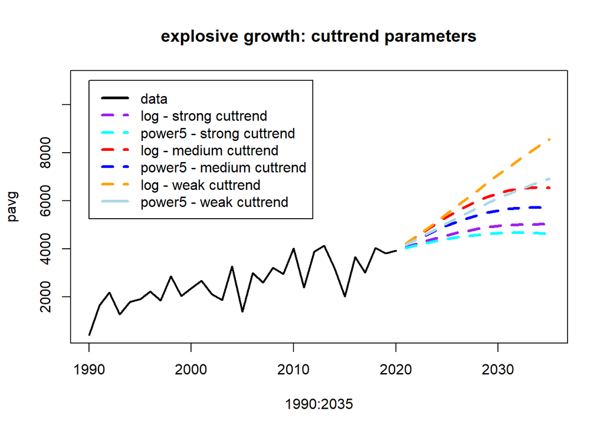

```r
cuttrend.vstrong <- seq(0.5,1,length.out=15)
cuttrend.strong <- seq(0,1,length.out=15)
cuttrend.weak <- seq(0,0.5,length.out=15)
plot(1990:2035, pavg, type='l',lwd=2, ylim=c(500,11000),main='explosive growth: cuttrend parameters')
pred.log.vstrong <- multiAPCMC.singlepred(multiAPCMC.singlefit.object=fit.log,
                    futuredata=fc.fut10,
                    noproj=length(p),
                    cuttrend=cuttrend.vstrong)
pred.p5.vstrong <- multiAPCMC.singlepred(multiAPCMC.singlefit.object=fit.p5,
                    futuredata=fc.fut10,
                    noproj=length(p),
                    cuttrend=cuttrend.vstrong)
pred.log.medium <- multiAPCMC.singlepred(multiAPCMC.singlefit.object=fit.log,
                    futuredata=fc.fut10,
                    noproj=length(p),
                    cuttrend=cuttrend.strong)
pred.p5.medium <- multiAPCMC.singlepred(multiAPCMC.singlefit.object=fit.p5,
                    futuredata=fc.fut10,
                    noproj=length(p),
                    cuttrend=cuttrend.strong)
pred.log.weak <- multiAPCMC.singlepred(multiAPCMC.singlefit.object=fit.log,
                    futuredata=fc.fut10,
                    noproj=length(p),
                    cuttrend=cuttrend.weak)
pred.p5.weak <- multiAPCMC.singlepred(multiAPCMC.singlefit.object=fit.p5,
                    futuredata=fc.fut10,
                    noproj=length(p),
                    cuttrend=cuttrend.weak)
incyear.pred.log.vstrong <- multiAPCMC.predsummary(years,pred.log.vstrong)
incyear.pred.p5.vstrong <- multiAPCMC.predsummary(years,pred.p5.vstrong)
incyear.pred.log.medium <- multiAPCMC.predsummary(years,pred.log.medium)
incyear.pred.p5.medium <- multiAPCMC.predsummary(years,pred.p5.medium)
incyear.pred.log.weak <- multiAPCMC.predsummary(years,pred.log.weak)
incyear.pred.p5.weak <- multiAPCMC.predsummary(years,pred.p5.weak)
lines(years,c(rep(NA,31),incyear.pred.log.vstrong$pred[32:46]), col='purple', lty=2,lwd=3)
lines(years,c(rep(NA,31),incyear.pred.p5.vstrong$pred[32:46]), col='cyan', lty=2,lwd=3)
lines(years,c(rep(NA,31),incyear.pred.log.medium$pred[32:46]), col='red', lty=2,lwd=3)
lines(years,c(rep(NA,31),incyear.pred.p5.medium$pred[32:46]), col='blue', lty=2,lwd=3)
lines(years,c(rep(NA,31),incyear.pred.log.weak$pred[32:46]), col='orange', lty=2,lwd=3)
lines(years,c(rep(NA,31),incyear.pred.p5.weak$pred[32:46]), col='lightblue', lty=2,lwd=3)
legend(1990,11000,legend=c('data','log - strong cuttrend', 'power5 - strong cuttrend', 'log - medium cuttrend', 'power5 - medium cuttrend', 'log - weak cuttrend', 'power5 - weak cuttrend'),lty=c(1,2,2,2,2,2),col=c('black','purple','cyan','red','blue','orange','lightblue'),lwd=3)
```

Some of these cuttrend parameters do a good job. The weak ones might not be strong enough. Whether the medium or strong ones are best however, depend on who you ask. We could try out a few other options for the cuttrend as well.

That is my main message here: choosing a cuttrend parameter works, but it is a highly subjective exercise. Within certain bounds (growth, decline) it allows us to essentially choose which trend we want to see in the future. But if we find it acceptable that we can choose the future trend, why are we going through all this technical effort anyway? Then we might as well just give a pen to a scholar and ask them to draw the line. Of course, it is always good to examine your forecasted trends to see if they make sense. But I do not think we should have the level of control that the cuttrend parameter allows us. At least, not without some additional safeguards.

Solutions

I see three ways forward.

1. We keep the cuttrend parameter, but we make it part of the validation step. In other words, the cuttrend parameter becomes a hyperparameter, which we can tune using leave-future-out validation.
2. We use a regularization method, such as a penalty parameter in a LASSO or a tight Bayesian prior, to limit the size that the drift component can take. By limiting the drift, we cannot have explosive extrapolation. However, the penalty parameter or tight Bayesian prior also needs a validations step to determine its value.
3. We do not use a log-link function or a power5 link function in the APC model. An alternative could be to use an identity link (i.e. ‘ordinary’ linear regression). This could work when incidences are far away from 0, so that no incidence below 0 is predicted. Or, perhaps some modified version of linear regression where the variance becomes partially coupled to the mean in the same way as in a model with a Poisson or negative binomial outcome distribution (low values: low outcome variance, high values, high outcome variance). This can also guard against predicting negative incidence.